# REC - Gestão Estratégica de TI

22 de Março de 2022

Usaremos um dataset com registros diários de aluguel desde 2011 a 2012.

# Sobre o aluguel de bikes em DC, EUA

Os sistemas de compartilhamento de bicicletas são a nova geração de sistemas tradicionais de aluguel de bicicletas onde todo o processo de adesão, aluguel e retorno se tornou automático. Através destes sistemas, o usuário é capaz de alugar facilmente uma bicicleta de uma determinada posição e retornar em outra posição. Atualmente, existem cerca de 500 programas de compartilhamento de bicicletas em todo o mundo, que é composto de mais de 500 mil bicicletas. Hoje, existe um grande interesse nestes sistemas devido ao seu importante papel em questões de tráfego, meio ambiente e saúde.

Além das aplicações interessantes no mundo real dos sistemas de aluguel de bicicletas, as características dos dados gerados por estes sistemas os tornam atraentes para a pesquisa. Ao contrário de outros serviços de transporte, como ônibus ou metrô, a duração da viagem, posição de partida e chegada é explicitamente registrada nestes sistemas. Esta característica transforma o sistema de compartilhamento de bicicletas em uma rede virtual de sensores que pode ser usada para a detecção da mobilidade na cidade. Portanto, espera-se que a maioria dos eventos importantes na cidade possam ser detectados através do monitoramento destes dados.

Fonte: [UCI Machine Learning Repository - Bike Sharing Dataset](http://archive.ics.uci.edu/ml/datasets/Bike+Sharing+Dataset)

# Dados

Os dados incluem contagens diárias de aluguel de bicicletas (por membros e usuários casuais) da “Capital Bikeshare” em Washington, DC entre 2011 e 2012, bem como informações meteorológicas sobre esses dias.

As fontes de dados originais se encontram em: http://capitalbikeshare.com/system-data e http://www.freemeteo.com.

O dataset chama-se `dcbikeshare-day.csv`.

# Questões

1. Recodifique a variável `season` para um *factor* com nomes mais significativos para cada nível, considerando a “primavera” **spring** como categoria base. (*Valor: 0,5 pts*)
2. Recodifique as variáveis binárias `holiday` e `workingday` para serem fatores com níveis não (0) e sim (1), com “não” como categoria base. (*Valor: 0,5 pts*)
3. Recodifique a variável `yr` para ser um fator com níveis 2011 e 2012, com 2011 como categoria base. (*Valor: 0,5 pts*)
4. Recodifique a variável `weathersit` para: 1 - claro, 2 - névoa, 3 - precipitação leve, e 4 - precipitação pesada, com “claro” como categoria base. (*Valor: 0,5 pts*)
5. Recodifique a variável `dteday` para formato “Date” e a variável `mnth` para **factor** com 12 níveis. (*Valor: 0,5 pts*)
6. Calcule os valores brutos de temperatura (`temp`), sensação térmica (`atemp`), umidade (`hum`) e velocidade do vento (`windspeed`) a partir da multiplicação dos valores indicados no dataset *dcbikeshare* pelos valores máximos brutos indicados na tabela abaixo:

| Variável | Valor Máximo |
| --- | --- |
| temp | 41 |
| atemp | 50 |
| hum | 100 |
| windspeed | 67 |

E inclua as novas variáveis `temp_real`, `atemp_real`,`hum_real`,`windspeed_real` no dataframe. (*Valor: 0,5 pts*)

7. Recrie a seguinte visualização, e interprete-a no contexto dos dados. Obs: A temperatura plotada é a sensação térmica *atemp*. (*Valor: 0,5 pts*)

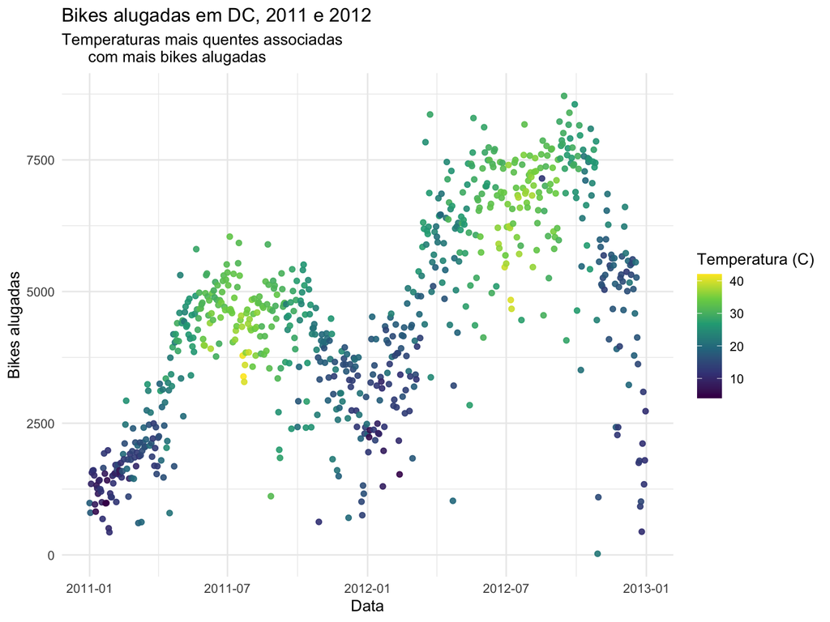

8. Crie uma visualização *Boxplot* mostrando a relação entre o aluguel de bicicletas e a estação do ano (`season`). Interprete-a no contexto dos dados. (*Valor: 0,5 pts*)
9. Crie um novo dataset com as variáveis: `season`, `yr`,`mnth`, `holiday`, `workingday`, `weathersit`, `temp_real`, `atemp_real`, `hum_real`, `windspeed_real` e `cnt`. Logo, separe-o em dois grupos, treinamento e teste, sendo a proporção 75 e 25 respectivamente. (*Valor: 0,5 pts*)
10. Utilize o k-fold cross validation ou validação cruzada, com 10 dobras e treine o algoritmo **árvore de decisão** com as variáveis preditoras: `season`, `yr`,`mnth`, `holiday`, `workingday`, `weathersit`, `temp_real`, `atemp_real`, `hum_real`, `windspeed_real`, para o dataset de treino (lembrando que a variável de saída é `cnt`. Reporte os valores de $R^2$, *RMSE* e *MAE*. (*Valor: 1,5 pts*)
11. Refaça a questão 10 só que agora usando o algoritmo **Random Forests** com 1000 árvores. Reporte os valores de $R^2$, *RMSE* e *MAE*. (*Valor: 1,5 pts*)
12. Destes dois modelos, escolha aquele com a melhor precisão com base nos valores $R^2$, *RMSE* e *MAE* e use-o para verificar o resultado final com o dataset de teste. Reporte os valores de $R^2$, *RMSE* e *MAE* para o dataset de teste. (*Valor: 1,5 pts*)
13. Reproduza o gráfico a seguir, onde no eixo “x” temos `cnt` e no eixo “y”, o valor da previsão. (*Valor: 1 pts*)

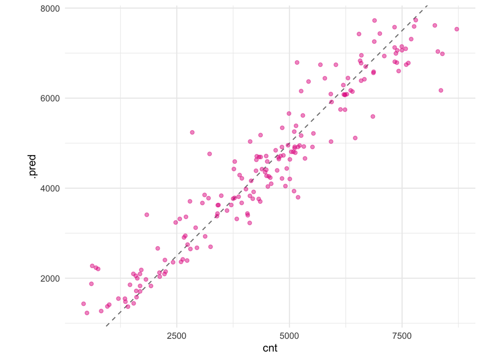